# 7. Convolutional Neural Networks

- Show All Code
- Hide All Code
- View Source

Dive-into-Deep-Learning

Introduction to the convolutional layers, including padding and stride, the pooling layers used to aggregate information across adjacent spatial regions, the use of multiple channels at each layer, and a careful discussion of the structure of modern architectures.

Author

Wu Hao

Published

2025/2/14

# From Fully Connected Layers to Convolutions

In these cases, an MLP may be the best that we can do. However, for high-dimensional perceptual data, such structureless networks can grow unwieldy.

## Invariance

1. In the earliest layers, our network should respond similarly to the same patch, regardless of where it appears in the image. This principle is called translation invariance (or translation equivariance).
2. The earliest layers of the network should focus on local regions, without regard for the contents of the image in distant regions. This is the locality principle. Eventually, these local representations can be aggregated to make predictions at the whole image level.
3. As we proceed, deeper layers should be able to capture longer-range features of the image, in a way similar to higher level vision in nature.

## Constraining the MLP

To start off, we can consider an MLP with two-dimensional images $X$ as inputs and their immediate hidden representations $H$ similarly represented as matrices.

Let $[X]_{i,j}$ and $[H]_{i,j}$ denote the pixel at location $(i,j)$ in the input image and hidden representations. Consequently, to have each of the hidden units receive input from each of the input pixels, we would switch from using weight matrices (as we did previously in MLPs) to representing our parameters as fourth-order weight tensors $W$.

Suppose that $U$ contains biases, we could formally express the fully connected layer as:

$$[\mathbf{H}]_{i,j} = [\mathbf{U}]_{i,j} + \sum_k \sum_l [\mathbf{W}]_{i,j,k,l} [\mathbf{X}]_{k,l}= [\mathbf{U}]_{i,j} + \sum_a \sum_b [\mathbf{V}]_{i,j,a,b} [\mathbf{X}]_{i+a,j+b}.$$

However, in this case, the computation depends on specific indices $(i,j)$, preventing translation invariance.

### Translation Invariance

We can employ the Convolutional Filters.

$$[\mathbf{H}]_{i,j} = u + \sum_{a,b} [\mathbf{V}]_{a,b} [\mathbf{X}]_{i+a,j+b}.$$

Here, the weights $[V]_{a,b}$ do not depend on absolute positions $(i,j)$, meaning the same convolutional kernel is applied across the entire image.

### Locality

Locality means that each neuron should only consider a small local region of the image instead of the entire image when computing features. This reduces the number of parameters and improves computational efficiency.

To enforce locality, we can restrict the receptive field as follows:

$$[\mathbf{H}]_{i,j} = u + \sum_{a=-\Delta}^{\Delta} \sum_{b=-\Delta}^{\Delta} [\mathbf{V}]_{a,b} [\mathbf{X}]_{i+a,j+b}.$$

where $\Delta$ defines the size of the receptive field, ensuring that only nearby pixels contribute to the computation.

## Channels

Images are not two-dimensional objects but rather third-order tensors, characterized by a height, width, and channel (red, green, and blue), e.g., with shape $1024 \times 1024 \times 3$ pixels. While the first two of these axes concern spatial relationships, the third can be regarded as assigning a multidimensional representation to each pixel location. We thus index $X$ as $[X]_{i,j,k}$. The convolutional filter has to adapt accordingly. Instead of $[V]_{a,b}$, we now have $[V]_{a,b,c}$.

Since the input image is 3D, the hidden representations $H$ (feature maps) should also be 3D. Instead of a single hidden matrix, we maintain multiple 2D feature maps, where each feature map learns different aspects of the image.

Think of each channel as detecting a different feature. Some channels might focus on edges, while others capture textures or patterns. Thus, CNN layers do not just output a single 2D feature map but rather a set of feature maps, making the representation richer and more informative.

To support multiple channels in both inputs ($X$) and hidden representations ($H$), we can add a fourth coordinate to $V$: $[V]_{a,b,c,d}$. Putting everything together we have:

$$[\mathbf{H}]_{i,j,d} = \sum_{a=-\Delta}^{\Delta} \sum_{b=-\Delta}^{\Delta} \sum_c [\mathbf{V}]_{a,b,c,d} [\mathbf{X}]_{i+a,j+b,c},$$

where $c$ represents the input channels, $d$ represents the output channels.

# Convolutions for Images

Now that we understand how convolutional layers work in theory, we are ready to see how they work in practice. Building on our motivation of convolutional neural networks as efficient architectures for exploring structure in image data, we stick with images as our running example.

```python
import torch
from torch import nn
from d2l import torch as d2l
import torchvision
from torch.utils import data
from torch.utils.data import DataLoader
from torchvision import transforms
import time
import numpy as np
```

## The Cross-Correlation Operation

Convolutional layers in deep learning use *cross-correlation*, not the strict mathematical convolution operation. In cross-correlation, an input tensor and a kernel (filter) are combined to produce an output tensor.

In 2D cross-correlation process, the kernel slides over the input matrix from left to right and top to bottom. At each position, element-wise multiplication is performed between the kernel and the corresponding subregion of the input. The sum of these multiplications produces a single scalar value for the output tensor at that location.

The output size shrinks because the kernel cannot extend beyond the input boundaries. The formula for the output size is: $(n_h-k_h+1) \times (n_w-k_w+1)$, where $n_h,n_w$ are the input height and width and $k_h, k_w$ are the kernel height and width.

Next, we implement this process in the `corr2d` function, which accepts an input tensor X and a kernel tensor K and returns an output tensor Y.

```python
def corr2d(X, K):
    """Compute 2D cross-correlation."""
    h, w = K.shape
    Y = torch.zeros((X.shape[0] - h + 1, X.shape[1] - w + 1))
    for i in range(Y.shape[0]):
        for j in range(Y.shape[1]):
            Y[i, j] = (X[i:i + h, j:j + w] * K).sum()
    return Y

X = torch.tensor([[0.0, 1.0, 2.0], [3.0, 4.0, 5.0], [6.0, 7.0, 8.0]])
K = torch.tensor([[0.0, 1.0], [2.0, 3.0]])
corr2d(X, K)
```

```
tensor([[19., 25.],
        [37., 43.]])
```

## Convolutional Layers

A convolutional layer cross-correlates the input and kernel and adds a scalar bias to produce an output. We are now ready to implement a two-dimensional convolutional layer based on the `corr2d` function defined above. The forward propagation method calls the `corr2d` function and adds the bias.

```python
class Conv2D(nn.Module):
    def __init__(self, kernel_size):
        super().__init__()
        self.weight = nn.Parameter(torch.rand(kernel_size))
        self.bias = nn.Parameter(torch.zeros(1))

    def forward(self, x):
        return corr2d(x, self.weight) + self.bias
```

## Objection Edge Detection in Images

First, we construct an “image” of $6 \times 8$ pixels. The middle four columns are black (0 ) and the rest are white (1).

Next, we construct a kernel K with a height of 1 and a width of 2. When we perform the cross-correlation operation with the input, if the horizontally adjacent elements are the same, the output is 0. Otherwise, the output is nonzero.

```python
X = torch.ones((6,8))
X[:, 2:6] = 0

K = torch.tensor([[1.0, -1.0]])
Y = corr2d(X,K)
Y
```

```
tensor([[ 0.,  1.,  0.,  0.,  0., -1.,  0.],
        [ 0.,  1.,  0.,  0.,  0., -1.,  0.],
        [ 0.,  1.,  0.,  0.,  0., -1.,  0.],
        [ 0.,  1.,  0.,  0.,  0., -1.,  0.],
        [ 0.,  1.,  0.,  0.,  0., -1.,  0.],
        [ 0.,  1.,  0.,  0.,  0., -1.,  0.]])
```

We can now apply the kernel to the transposed image. As expected, it vanishes. The kernel K only detects vertical edges.

```python
corr2d(X.t(), K)
```

```
tensor([[0., 0., 0., 0., 0.],
        [0., 0., 0., 0., 0.],
        [0., 0., 0., 0., 0.],
        [0., 0., 0., 0., 0.],
        [0., 0., 0., 0., 0.],
        [0., 0., 0., 0., 0.],
        [0., 0., 0., 0., 0.],
        [0., 0., 0., 0., 0.]])
```

## Learning a Kernel

Designing an edge detector by finite differences [1, -1] is neat if we know this is precisely what we are looking for. However, as we look at larger kernels, and consider successive layers of convolutions, it might be impossible to specify precisely what each filter should be doing manually.

Now let’s see whether we can learn the kernel that generated Y from X by looking at the input–output pairs only.

```python
conv2d = nn.LazyConv2d(1, kernel_size=(1,2), bias=False)

# The two-dimensional convolutional layer uses four-dimensional input and
# output in the format of (example, channel, height, width), where the batch
# size (number of examples in the batch) and the number of channels are both 1
X = X.reshape((1,1,6,8))
Y = Y.reshape((1,1,6,7))
lr = 3e-2

for i in range(10):
  Y_hat = conv2d(X)
  l = (Y_hat - Y) **2
  conv2d.zero_grad()
  l.sum().backward()
  #update the kernel
  conv2d.weight.data[:] -= lr*conv2d.weight.grad
  if (i+1)%2 == 0:
    print(f'epoch {i + 1}, loss {l.sum():.3f}, kernel {conv2d.weight.data.reshape((1,2))}')
```

```
epoch 2, loss 8.901, kernel tensor([[ 0.3740, -0.7427]])
epoch 4, loss 2.264, kernel tensor([[ 0.7011, -0.9371]])
epoch 6, loss 0.695, kernel tensor([[ 0.8504, -1.0014]])
epoch 8, loss 0.246, kernel tensor([[ 0.9213, -1.0180]])
epoch 10, loss 0.094, kernel tensor([[ 0.9566, -1.0185]])
```

## Feature Map and Receptive Field

The convolutional layer output in is sometimes called a feature map, as it can be regarded as the learned representations (features) in the spatial dimensions (e.g., width and height) to the subsequent layer. In CNNs, for any element $x$ of some layer, its receptive field refers to all the elements (from all the previous layers) that may affect the calculation of $x$ during the forward propagation. Note that the receptive field may be larger than the actual size of the input.

# Padding and Stride

As motivation, note that since kernels generally have width and height greater than , after applying many successive convolutions, we tend to wind up with outputs that are considerably smaller than our input. If we start with a $240 \times 240$ pixel image, ten layers of $5 \times 5$ convolutions reduce the image to $200 \times 200$ pixels, slicing off $30 \%$ of the image and with it obliterating any interesting information on the boundaries of the original image. *Padding* is the most popular tool for handling this issue. In other cases, we may want to reduce the dimensionality drastically, e.g., if we find the original input resolution to be unwieldy. *Strided convolutions* are a popular technique that can help in these instances.

## Padding

In general, if we add a total of $p_h$ rows of padding and a total of $p_w$ columns of padding, the output shape will be:

$$(n_h-k_h+p_h+1) \times (n_w-k_w+p_w+1)$$

This means that the height and width of the output will increase by $p_h$ and $p_w$, respectively.

CNNs commonly use convolution kernels with odd height and width values, such as 1, 3, 5, or 7. Choosing odd kernel sizes has the benefit that we can preserve the dimensionality while padding with the same number of rows on top and bottom, and the same number of columns on left and right.

In the following example, we create a two-dimensional convolutional layer with a height and width of 3 and apply 1 pixel of padding on all sides. Given an input with a height and width of 8, we find that the height and width of the output is also 8.

```python
def comp_conv2d(conv2d, X):
    X = X.reshape((1,1) + X.shape)
    Y = conv2d(X)
    return Y.reshape(Y.shape[2:])

conv2d = nn.LazyConv2d(1, kernel_size=3, padding=1)
X = torch.rand(size=(8, 8))
comp_conv2d(conv2d, X).shape
```

```
torch.Size([8, 8])
```

When the height and width of the convolution kernel are different, we can make the output and input have the same height and width by setting different padding numbers for height and width.

```python
# We use a convolution kernel with height 5 and width 3. The padding on either
# side of the height and width are 2 and 1, respectively
conv2d = nn.LazyConv2d(1, kernel_size=(5, 3), padding=(2, 1))
comp_conv2d(conv2d, X).shape
```

```
torch.Size([8, 8])
```

## Stride

When computing the cross-correlation, we start with the convolution window at the upper-left corner of the input tensor, and then slide it over all locations both down and to the right. However, sometimes, either for computational efficiency or because we wish to downsample, we move our window more than one element at a time, skipping the intermediate locations. This is particularly useful if the convolution kernel is large since it captures a large area of the underlying image. We refer to the number of rows and columns traversed per slide as *stride*.

In general, when the stride for the height is $s_h$ and the stride for the width is $s_w$, the output shape is:

$$\left\lfloor{(n_h - k_h + p_h + s_h)}{s_h} \right\rfloor \times \left\lfloor {(n_w - k_w + p_w + s_w)}{s_w} \right\rfloor.$$

Below, we set the strides on both the height and width to 2, thus halving the input height and width.

```python
conv2d = nn.LazyConv2d(1, kernel_size=3, padding=1, stride=2)
comp_conv2d(conv2d, X).shape
```

```
torch.Size([4, 4])
```

# Multiple Input and Multiple Output Channels

Until now, we simplified all of our numerical examples by working with just a single input and a single output channel. When we add channels into the mix, our inputs and hidden representations both become three-dimensional tensors. or example, each RGB input image has shape $3 \times h \times w$.

## Multiple Input Channels

When the input data contains multiple channels, we need to construct a convolution kernel with the same number of input channels as the input data, so that it can perform cross-correlation with the input data.

The shaded portions are the first output element as well as the input and kernel tensor elements used for the output computation:

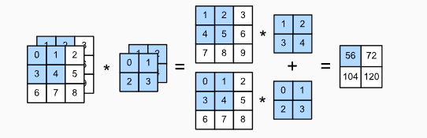

Cross-correlation computation with two input channels.

```python
def corr2d_multi_in(X, K):
    # Iterate through the 0th dimension (channel) of K first, then add them up
    return sum(d2l.corr2d(x, k) for x, k in zip(X, K))

X = torch.tensor([[[0.0, 1.0, 2.0], [3.0, 4.0, 5.0], [6.0, 7.0, 8.0]],
               [[1.0, 2.0, 3.0], [4.0, 5.0, 6.0], [7.0, 8.0, 9.0]]])
K = torch.tensor([[[0.0, 1.0], [2.0, 3.0]], [[1.0, 2.0], [3.0, 4.0]]])

corr2d_multi_in(X, K)
```

```
tensor([[ 56.,  72.],
        [104., 120.]])
```

## Multiple Output Channels

Regardless of the number of input channels, so far we always ended up with one output channel. Intuitively, you could think of each channel as responding to a different set of features. The reality is a bit more complicated than this. A naive interpretation would suggest that representations are learned independently per pixel or per channel. Instead, channels are optimized to be jointly useful. This means that rather than mapping a single channel to an edge detector, it may simply mean that some direction in channel space corresponds to detecting edges.

In cross-correlation operations, the result on each output channel is calculated from the convolution kernel corresponding to that output channel and takes input from all channels in the input tensor. We implement a cross-correlation function to calculate the output of multiple channels as shown below.

```python
def corr2d_multi_in_out(X, K):
    # Iterate through the 0th dimension of K, and each time, perform
    # cross-correlation operations with input X. All of the results are
    # stacked together
    return torch.stack([corr2d_multi_in(X, k) for k in K], 0)

K = torch.stack((K, K + 1, K + 2), 0)
K.shape
```

```
torch.Size([3, 2, 2, 2])
```

Below, we perform cross-correlation operations on the input tensor X with the kernel tensor K. Now the output contains three channels. The result of the first channel is consistent with the result of the previous input tensor X and the multi-input channel, single-output channel kernel.

```python
corr2d_multi_in_out(X, K)
```

```
tensor([[[ 56.,  72.],
         [104., 120.]],

        [[ 76., 100.],
         [148., 172.]],

        [[ 96., 128.],
         [192., 224.]]])
```

## $1 \times 1$ Convolutional Layer

A $1 \times 1$ convolution is often used to adjust the number of channels (depth) of the input feature maps. It can map multiple input channels to a different number of output channels without changing the spatial dimensions (width and height) of the feature maps.

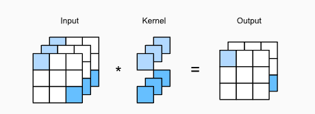

The cross-correlation computation uses the $1 \times 1$ convolution kernel with three input channels and two output channels. The input and output have the same height and width.

Let’s check whether this works in practice: we implement a $1 \times 1$ convolution using a fully connected layer. The only thing is that we need to make some adjustments to the data shape before and after the matrix multiplication.

```python
def corr2d_multi_in_out_1x1(X, K):
    c_i, h, w = X.shape
    c_o = K.shape[0]
    X = X.reshape((c_i, h * w))
    K = K.reshape((c_o, c_i))
    # Matrix multiplication in the fully connected layer
    Y = torch.matmul(K, X)
    return Y.reshape((c_o, h, w))

X = torch.normal(0, 1, (3, 3, 3))
K = torch.normal(0, 1, (2, 3, 1, 1))
Y1 = corr2d_multi_in_out_1x1(X, K)
Y2 = corr2d_multi_in_out(X, K)
assert float(torch.abs(Y1 - Y2).sum()) < 1e-6
```

# Pooling

Pooling is a downsampling operation commonly used in Convolutional Neural Networks (CNNs) to reduce the spatial dimensions (width and height) of the input feature maps while retaining important features. It serves several key purposes:

1. Pooling helps reduce the spatial size of the feature maps, which leads to fewer parameters and less computation. This also helps mitigate the risk of overfitting by reducing the model’s complexity.
2. Pooling introduces a level of spatial invariance. By selecting the most prominent feature from a region, pooling ensures that the network can still recognize patterns regardless of small translations, rotations, or distortions in the input.
3. By reducing the size of the feature maps, pooling significantly reduces the number of operations in subsequent layers, which leads to faster processing and more efficient memory usage.

## Maximum Pooling and Average Pooling

Like convolutional layers, pooling operators consist of a fixed-shape window that is slid over all regions in the input according to its stride, computing a single output for each location traversed by the fixed-shape window (sometimes known as the pooling window). However, unlike the cross-correlation computation of the inputs and kernels in the convolutional layer, the pooling layer contains no parameters (there is no kernel). Instead, pooling operators are deterministic, typically calculating either the maximum or the average value of the elements in the pooling window. These operations are called *maximum pooling* (max-pooling for short) and *average pooling*, respectively.

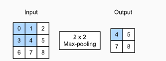

maximum pooling

We implement the forward propagation of the pooling layer in the `pool2d` function in the code below.

```python
def pool2d(X, pool_size, mode='max'):
    p_h, p_w = pool_size
    Y = torch.zeros((X.shape[0] - p_h + 1, X.shape[1] - p_w + 1))
    for i in range(Y.shape[0]):
        for j in range(Y.shape[1]):
            if mode == 'max':
                Y[i, j] = X[i: i + p_h, j: j + p_w].max()
            elif mode == 'avg':
                Y[i, j] = X[i: i + p_h, j: j + p_w].mean()
    return Y

X = torch.tensor([[0.0, 1.0, 2.0], [3.0, 4.0, 5.0], [6.0, 7.0, 8.0]])
pool2d(X, (2, 2))
pool2d(X, (2, 2), mode='avg')
```

```
tensor([[2., 3.],
        [5., 6.]])
```

## Padding and Stride

We can also demonstrate the use of padding and strides in pooling layers via the built-in two-dimensional max-pooling layer from the deep learning framework.

```python
X = torch.arange(16, dtype=torch.float32).reshape((1, 1, 4, 4))
print(f'X is {X}')

pool2d = nn.MaxPool2d(3)
# Pooling has no model parameters, hence it needs no initialization
print(f'X after pooling is {pool2d(X)}')

pool2d = nn.MaxPool2d(3, padding=1, stride=2)
pool2d(X)
```

```
X is tensor([[[[ 0.,  1.,  2.,  3.],
          [ 4.,  5.,  6.,  7.],
          [ 8.,  9., 10., 11.],
          [12., 13., 14., 15.]]]])
X after pooling is tensor([[[[10.]]]])
```

```
tensor([[[[ 5.,  7.],
          [13., 15.]]]])
```

## Multiple Channels

When processing multi-channel input data, the pooling layer pools each input channel separately, rather than summing the inputs up over channels as in a convolutional layer. This means that the number of output channels for the pooling layer is the same as the number of input channels. Below, we will concatenate tensors X and X + 1 on the channel dimension to construct an input with two channels.

```python
X = torch.cat((X, X + 1), 1)
print(f'X is {X}')

pool2d = nn.MaxPool2d(3, padding=1, stride=2)
pool2d(X)
```

```
X is tensor([[[[ 0.,  1.,  2.,  3.],
          [ 4.,  5.,  6.,  7.],
          [ 8.,  9., 10., 11.],
          [12., 13., 14., 15.]],

         [[ 1.,  2.,  3.,  4.],
          [ 5.,  6.,  7.,  8.],
          [ 9., 10., 11., 12.],
          [13., 14., 15., 16.]]]])
```

```
tensor([[[[ 5.,  7.],
          [13., 15.]],

         [[ 6.,  8.],
          [14., 16.]]]])
```

# Convolutional Neural Networks (LeNet)

In our earlier encounter with image data, we applied a linear model with softmax regression and an MLP to pictures of clothing in the Fashion-MNIST dataset. In this section, we will introduce LeNet, among the first published CNNs to capture wide attention for its performance on computer vision tasks.

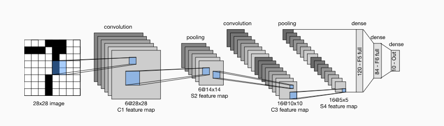

Data flow in LeNet. The input is a handwritten digit, the output is a probability over 10 possible outcomes.

The basic units in each convolutional block are a convolutional layer, a sigmoid activation function, and a subsequent average pooling operation.

```python
def init_weights(m):
    if type(m) == nn.Linear or type(m) == nn.Conv2d:
        nn.init.xavier_uniform_(m.weight)

class LeNet(d2l.Classifier):
    """The LeNet-5 model."""
    def __init__(self, lr=0.1, num_classes=10):
        super().__init__()
        self.save_hyperparameters()
        self.net = nn.Sequential(
            nn.Conv2d(1, 6, kernel_size=5, padding=2), nn.Sigmoid(),
            nn.AvgPool2d(kernel_size=2, stride=2),
            nn.Conv2d(6, 16, kernel_size=5), nn.Sigmoid(),
            nn.AvgPool2d(kernel_size=2, stride=2),
            nn.Flatten(),
            nn.Linear(16 * 5 * 5, 120), nn.Sigmoid(),
            nn.Linear(120, 84), nn.Sigmoid(),
            nn.Linear(84, 10))
    def layer_summary(self, X):
        for layer in self.net:
            X = layer(X)
            print(layer.__class__.__name__, 'output shape:\t', X.shape)
```

We have taken some liberty in the reproduction of LeNet insofar as we have replaced the Gaussian activation layer by a softmax layer. This greatly simplifies the implementation, not least due to the fact that the Gaussian decoder is rarely used nowadays. Other than that, this network matches the original LeNet-5 architecture.

Let’s see what happens inside the network. By passing a single-channel (black and white) $28 \times 28$ image through the network and printing the output shape at each layer.

```python
X = torch.rand(size=(1, 1, 28, 28), dtype=torch.float32)
model = LeNet()
model.layer_summary(X)
```

```
Conv2d output shape:     torch.Size([1, 6, 28, 28])
Sigmoid output shape:    torch.Size([1, 6, 28, 28])
AvgPool2d output shape:  torch.Size([1, 6, 14, 14])
Conv2d output shape:     torch.Size([1, 16, 10, 10])
Sigmoid output shape:    torch.Size([1, 16, 10, 10])
AvgPool2d output shape:  torch.Size([1, 16, 5, 5])
Flatten output shape:    torch.Size([1, 400])
Linear output shape:     torch.Size([1, 120])
Sigmoid output shape:    torch.Size([1, 120])
Linear output shape:     torch.Size([1, 84])
Sigmoid output shape:    torch.Size([1, 84])
Linear output shape:     torch.Size([1, 10])
```

## Training

Now that we have implemented the model, let’s run an experiment to see how the LeNet-5 model fares on Fashion-MNIST.

### GPU and Config

```python
device = 'cuda' if torch.cuda.is_available() else 'cpu'
config = {
    'n_epochs': 25,     # Number of epochs.
    'batch_size': 256,
    'learning_rate': 1e-3,
}
```

### Preprocessing the Data

```python
trans = transforms.ToTensor()
mnist_train = torchvision.datasets.FashionMNIST(root="./data", train=True, transform=trans, download = True)
mnist_test = torchvision.datasets.FashionMNIST(root="./data", train=False, transform=trans, download = True)

train_iter = DataLoader(mnist_train, config['batch_size'], shuffle= True)
test_iter = DataLoader(mnist_test, config['batch_size'])
```

### Start Training

```python
def trainer(train_iter, test_iter, model, config, device):

    #optimization algorithm (Adam).
    optimizer = torch.optim.Adam(model.parameters(), lr=config['learning_rate'])
    criterion = nn.CrossEntropyLoss()
    model.apply(init_weights)
    print('training on', device)
    model.to(device)

    n_epochs= config['n_epochs']

    for epoch in range(n_epochs):
        model.train()
        epoch_start_time = time.time()
        loss_record = []
        train_acc = 0.0
        #x: features, y: labels
        for X, y in train_iter:
            optimizer.zero_grad()               # Set gradient to zero.
            X, y = X.to(device), y.to(device)
            train_pred = model(X)
            batch_loss = criterion(train_pred, y)
            batch_loss.backward()               # Compute gradient(back propagation).
            optimizer.step()                    # Update parameters.
            train_acc += np.sum(np.argmax(train_pred.detach().cpu().numpy(), axis=1) == y.cpu().numpy())
            loss_record.append(batch_loss.detach().item()) #detach(): separation gradient

        mean_train_loss = sum(loss_record)/len(loss_record)
        train_acc = train_acc / len(mnist_train)

        model.eval() # Set our model to evaluation mode.
        loss_record = []
        test_acc = 0.0
        with torch.no_grad():
            for x, y in test_iter:
                x, y = x.to(device), y.to(device)
                test_pred = model(x)
                batch_loss = criterion(test_pred, y)
                test_acc += np.sum(np.argmax(test_pred.detach().cpu().numpy(), axis=1) == y.cpu().numpy())
                loss_record.append(batch_loss.item())

            mean_test_loss = sum(loss_record)/len(loss_record)
            test_acc = test_acc / len(mnist_test)
            print('[%03d/%03d] %2.2f sec(s) Train Acc: %3.6f Loss: %3.6f | Test Acc: %3.6f loss: %3.6f' % \
              (epoch + 1, n_epochs, time.time() - epoch_start_time, \
               train_acc, mean_train_loss, test_acc, mean_test_loss))

trainer(train_iter, test_iter, model, config, device)
```

```
training on cuda
[001/025] 3.03 sec(s) Train Acc: 0.340533 Loss: 1.830135 | Test Acc: 0.624200 loss: 1.002407
[002/025] 2.64 sec(s) Train Acc: 0.689233 Loss: 0.852001 | Test Acc: 0.717200 loss: 0.768938
[003/025] 2.73 sec(s) Train Acc: 0.734883 Loss: 0.700976 | Test Acc: 0.743700 loss: 0.663195
[004/025] 3.36 sec(s) Train Acc: 0.755083 Loss: 0.628720 | Test Acc: 0.763300 loss: 0.610009
[005/025] 3.74 sec(s) Train Acc: 0.777950 Loss: 0.575430 | Test Acc: 0.781000 loss: 0.566327
[006/025] 3.70 sec(s) Train Acc: 0.795083 Loss: 0.537899 | Test Acc: 0.789600 loss: 0.540676
[007/025] 3.68 sec(s) Train Acc: 0.812217 Loss: 0.506041 | Test Acc: 0.806500 loss: 0.510472
[008/025] 3.70 sec(s) Train Acc: 0.824750 Loss: 0.481013 | Test Acc: 0.816500 loss: 0.494635
[009/025] 3.70 sec(s) Train Acc: 0.831033 Loss: 0.463214 | Test Acc: 0.821700 loss: 0.478079
[010/025] 3.71 sec(s) Train Acc: 0.838083 Loss: 0.444567 | Test Acc: 0.825400 loss: 0.466675
[011/025] 3.72 sec(s) Train Acc: 0.844000 Loss: 0.430625 | Test Acc: 0.832700 loss: 0.448421
[012/025] 3.71 sec(s) Train Acc: 0.847533 Loss: 0.420741 | Test Acc: 0.831100 loss: 0.454354
[013/025] 3.72 sec(s) Train Acc: 0.850483 Loss: 0.410458 | Test Acc: 0.836800 loss: 0.437099
[014/025] 3.72 sec(s) Train Acc: 0.854117 Loss: 0.400033 | Test Acc: 0.843900 loss: 0.422493
[015/025] 3.73 sec(s) Train Acc: 0.857700 Loss: 0.391349 | Test Acc: 0.847600 loss: 0.416871
[016/025] 3.68 sec(s) Train Acc: 0.858567 Loss: 0.385299 | Test Acc: 0.852300 loss: 0.408173
[017/025] 3.71 sec(s) Train Acc: 0.862383 Loss: 0.375193 | Test Acc: 0.850300 loss: 0.400040
[018/025] 3.68 sec(s) Train Acc: 0.864967 Loss: 0.368812 | Test Acc: 0.853900 loss: 0.396951
[019/025] 3.69 sec(s) Train Acc: 0.867817 Loss: 0.361366 | Test Acc: 0.850100 loss: 0.393101
[020/025] 3.75 sec(s) Train Acc: 0.869917 Loss: 0.355924 | Test Acc: 0.853900 loss: 0.395170
[021/025] 3.81 sec(s) Train Acc: 0.870333 Loss: 0.351332 | Test Acc: 0.856800 loss: 0.381192
[022/025] 3.79 sec(s) Train Acc: 0.873683 Loss: 0.343539 | Test Acc: 0.859300 loss: 0.381038
[023/025] 3.81 sec(s) Train Acc: 0.875767 Loss: 0.339819 | Test Acc: 0.864000 loss: 0.366387
[024/025] 3.78 sec(s) Train Acc: 0.877200 Loss: 0.333856 | Test Acc: 0.864700 loss: 0.363095
[025/025] 3.72 sec(s) Train Acc: 0.878683 Loss: 0.330203 | Test Acc: 0.867700 loss: 0.357278
```

Back to top